# Activity Data Analysis

Anita

September 1, 2017

## Step1 : Load data from the csv file

```r
     acdata   <- read.csv("activity.csv")
```

## Step2: Calculate the total number of steps taken per day

## Plot a histogram of “dates” in (x axis) and “total number of steps taken per day” in (y axis)

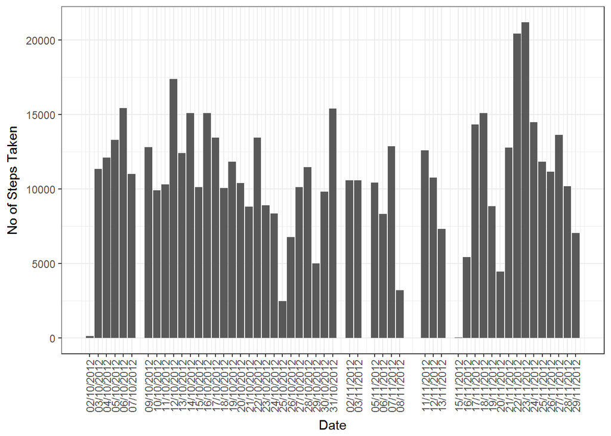

```r
       acsum    <- aggregate(steps~date, data=acdata, sum, na.rm=TRUE)
       acsum$date <- as.Date(acsum$date)
## Including Plots
       ggplot(acsum, aes(x = date, y = steps)) +
       geom_histogram(stat = "identity") +
       theme_bw() + labs(x = "Date", y = "No of Steps Taken") +
       scale_x_date(breaks =acsum$date,labels = date_format("%d/%m/%Y")) +
       theme(axis.text.x = element_text(angle=90, vjust = 0.5))
```

## Step3: Calculate the total mean and median of the number of steps taken per day

```r
       acdata1 <- na.omit(acdata[ acdata$steps != 0,])
       myFun <- function(x) {c(mean = mean(x), median = median(x))}
       newdata <- as.data.frame(cbind(date = unique(acdata1$date), do.call(rbind, tapply(acdata1$steps, acdata1$date, myFun))))
```

## Step4: Calculate the average number of steps taken in a 5-minute interval, averaged across all days for that interval

## Make a time series plot (i.e. type = “l”) of the 5-minute interval (x-axis) and the average number of steps taken,

## averaged across all days (y-axis)

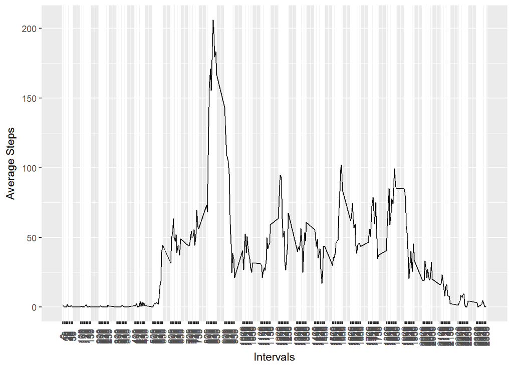

```r
       acaverage  <- as.data.frame(aggregate(steps~interval, data=acdata, mean, na.rm=TRUE))


       ggplot(acaverage, aes(x=interval, y=steps)) + geom_line() +
       scale_x_continuous(breaks =acaverage$interval)+ xlab("Intervals") + ylab("Average Steps")+
       theme(axis.text.x = element_text(angle=90, vjust = 0.5))
```

## Step5: Calculate which 5-minute interval, on average across all the days in the dataset, contains the maximum number of steps

```r
       maxvalue <- acaverage[which.max(acaverage$steps),]
       maxvalue
```

```
##     interval    steps
## 104      835 206.1698
```

## Step6: Calculate and print the total number of rows with missing (NA) values in the dataset

```r
       na_count <- sum(is.na(acdata$steps))
       na_count
```

```
## [1] 2304
```

## Step 7: Create a new dataset (acdatanew) and replace NA values with the Mean value of the “Number of Steps”

```r
      acdatanew <- acdata
      acdatanew$steps[which(is.na(acdatanew$steps))] <- mean(acdatanew$steps, na.rm=TRUE)
```

## Make a histogram of the total number of steps taken each day

## Plot a histogram of “dates” in (x axis) and “total number of steps taken per day”

## in (y axis)

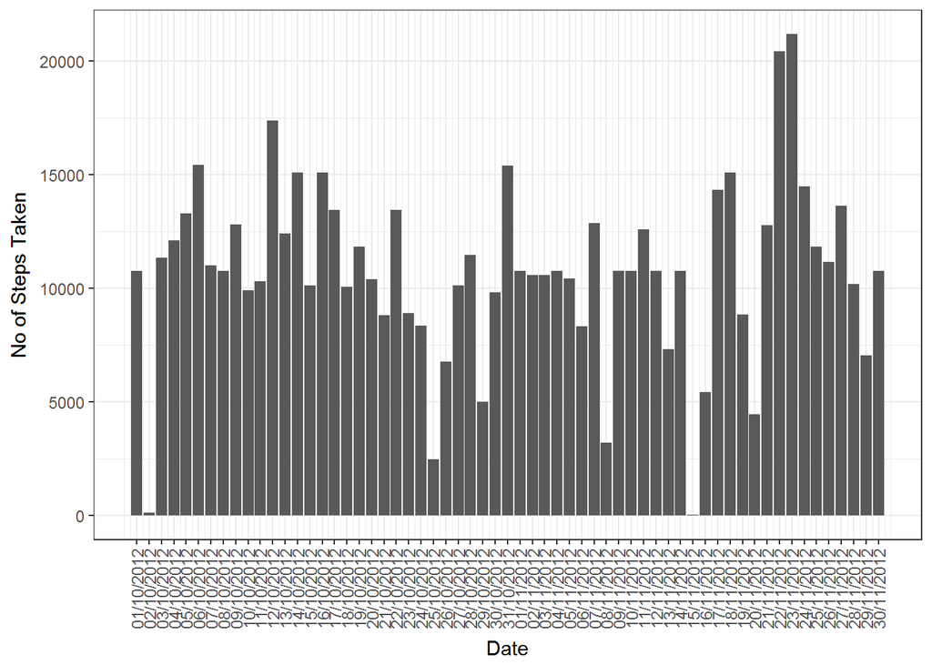

```r
      acsum1    <- aggregate(steps~date, data=acdatanew, sum, na.rm=TRUE)
      acsum1$date <- as.Date(acsum1$date)



      ggplot(acsum1, aes(x = date, y = steps)) +
      geom_histogram(stat = "identity") +
      theme_bw() + labs(x = "Date", y = "No of Steps Taken") +
      scale_x_date(breaks =acsum1$date,labels = date_format("%d/%m/%Y")) +
      theme(axis.text.x = element_text(angle=90, vjust = 0.5))
```

## Step 8: Calculate the total mean and median of the number of steps taken per day on the

## data that has filled NA values created in Step &

```r
      acdata1  <- na.omit(acdatanew[ acdatanew$steps != 0,])
      myFunNew <- function(x) {c(mean = mean(x), median = median(x))}
      newdata1 <- as.data.frame(cbind(Date = unique(acdata1$date), do.call(rbind, tapply(acdata1$steps, acdata1$date, myFunNew))))
```

## Step 9: Calculate and plot weekday vs weekend activity details using the following steps

## Take the data where the NA values were replaced with the Mean value of the “Number of Steps”

## Add a weekday column that contains the day of the week(Monday to Sunday) in it

## Remove all rows containing zero steps

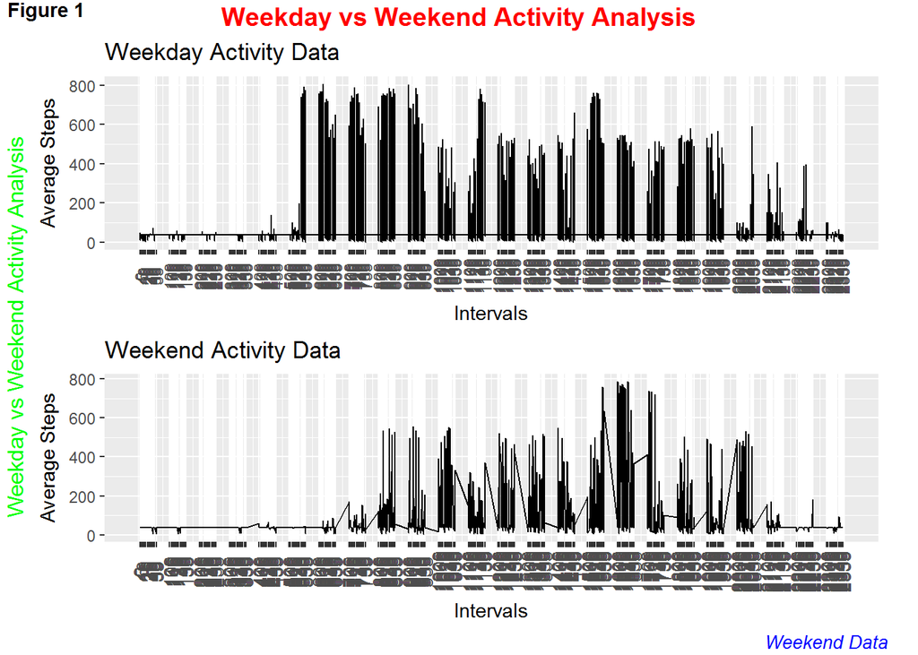

```r
      acdatanew$date <- as.Date(acdatanew$date,origin="1960-10-01")
      acdatanew$weekday <- weekdays(acdatanew$date, abbreviate = FALSE)
      acdatanew <- acdatanew[acdatanew$steps != 0,]

## Split the dataframe into two subsets. "weekdaydata" containing data for weekdays. "weekenddata' containing data for weekends.

      weekdaydata <- subset(acdatanew, subset=!(acdatanew$weekday=="Saturday"|acdatanew$weekday=="Sunday"))
      weekenddata <- subset(acdatanew, acdatanew$weekday == c("Saturday","Sunday"),na.rm=T)


## Make a time series plot (i.e. type = "l") of the 5-minute interval (x-axis) and the average number of steps taken,
## averaged across all Weekdays (y-axis)


      wdp <- ggplot(weekdaydata, aes(x=interval, y=steps)) + geom_line() +
      scale_x_continuous(breaks =acaverage$interval)+ xlab("Intervals") + ylab("Average Steps")+
      theme(axis.text.x = element_text(angle=90, vjust = 0.5))+ ggtitle("Weekday Activity Data")

## Make a time series plot (i.e. type = "l") of the 5-minute interval (x-axis) and the average number of steps taken,
## averaged across all Weekends (y-axis)

      wep <- ggplot(weekenddata, aes(x=interval, y=steps)) + geom_line() +
      scale_x_continuous(breaks =acaverage$interval)+ xlab("Intervals") + ylab("Average Steps")+
      theme(axis.text.x = element_text(angle=90, vjust = 0.5))+ggtitle("Weekend Activity Data")

## use ggarrange to overlap the plots

        figure <- ggarrange(wdp, wep + font("x.text", size = 10),
                ncol = 1, nrow = 2)
                annotate_figure(figure,
                top = text_grob("Weekday vs Weekend Activity Analysis", color = "red", face = "bold", size = 14),
                bottom = text_grob("Weekend Data", color = "blue",
                                   hjust = 1, x = 1, face = "italic", size = 10),
                left = text_grob("Weekday vs Weekend Activity Analysis", color = "green", rot = 90),
                right = "",
                fig.lab = "Figure 1", fig.lab.face = "bold"
                )
```